# LWB Quality Narrative Analysis

Amy Shuff

2024-02-01

Notes from Kaitlyn: Look only at Texas Rising Star Activity Category. Remove the words Texas Rising Star from word counts. Group by Board. Analyze Activity Description to see what most common categories of spending are. Look at differences across workforce boards.

Key words to do specific counts on:

Phrase(s) - Notes

- Child Development Associate (CDA) - key credential
- Early Childhood Education (ECE)
- Texas Rising Star (TRS) - QRIS system
- Early learning
- star level - Related to TRS
- Entry level - RElated to TRS
- professional development
- child care
- early childhood
- child development

Next Steps:

- Look at other categories and how many reference TRS in the non-TRS categories
- How and where are they investing
- How many regions mention salary related words in the TRS category
- Could be interesting to import budgets and see if there’s a corrolation with descriptions

# Methodology

This report will be analyzing Texas Workforce Commission (TWC) Boards quarterly reports for Child Care Quality (CCQ) Funds.

The original report can be found on the TWC website for Child Care Data, Reports & Plans: https://www.twc.texas.gov/programs/child-care/data-reports-plans

Under the dropdown titled “Local Board Child Care Quality (CCQ) Funds: Annual Plans and Quarterly Expenditure Reports”, we downloaded the FY23 CCQ Quarterly Online Report: https://www.twc.texas.gov/sites/default/files/ccel/docs/fy23-ccq-quarterly-online-report-updated-twc.xlsx

Specifically, we’ll be analyzing the third tab, titled “YTD Narratives,” focusing on the activity descriptions and measurable outcomes for the Texas Rising Star Activity Category.

The TidyText R package is being utilized for this analysis: https://www.tidytextmining.com/tidytext

The code for this project is available to the public on github: https://github.com/amyshuff/LWB-Quality-Narrative-Analysis

# TRS Activity Category

## Word Count

Stop words (common words such as “it”, “the”, “to”, etc.) were removed along with numbers and punctuation.

For this word count, we also removed TRS, Texas Rising Star, since it is assumed to be common.

Let’s start by seeing how much text we have to work with for each region.

Total Words in TRS Activity Category

| Region | Total Words |
| --- | --- |
| North Central Texas | 1219 |
| Capital Area | 657 |
| South Texas | 577 |
| Central Texas | 552 |
| Tarrant | 341 |
| Texoma | 315 |
| Rural Capital | 232 |
| North Texas | 215 |
| Gulf Coast | 198 |
| South Plains | 190 |
| Cameron | 175 |
| Lower Rio | 165 |
| West Central | 165 |
| Deep East | 159 |
| Dallas | 84 |
| Permian Basin | 81 |
| Northeast Texas | 74 |
| Panhandle | 67 |
| Alamo | 66 |
| Golden Crescent | 64 |
| East Texas | 57 |
| Brazos Valley | 48 |
| Heart of Texas | 36 |
| Coastal Bend | 27 |
| Concho Valley | 9 |
| Southeast | 8 |
| Borderplex | 7 |

We can see here that there is a large discrepancy in the amount of text for each region. Some only have a single sentence of less than ten words, while others have over a thousands words of text. Going forward, Concho Valley, Southeast, and Borderplex should have asterisks next to their names to remind us that we’re analyzing extremely limited data.

10 Most Frequently Used Words for all Regions Combined

| word | n | rank |
| --- | --- | --- |
| programs | 165 | 1 |
| providers | 113 | 2 |
| staff | 111 | 3 |
| early | 95 | 4 |
| increase | 95 | 5 |
| materials | 87 | 6 |
| learning | 82 | 7 |
| level | 73 | 8 |
| quality | 72 | 9 |
| provided | 71 | 10 |

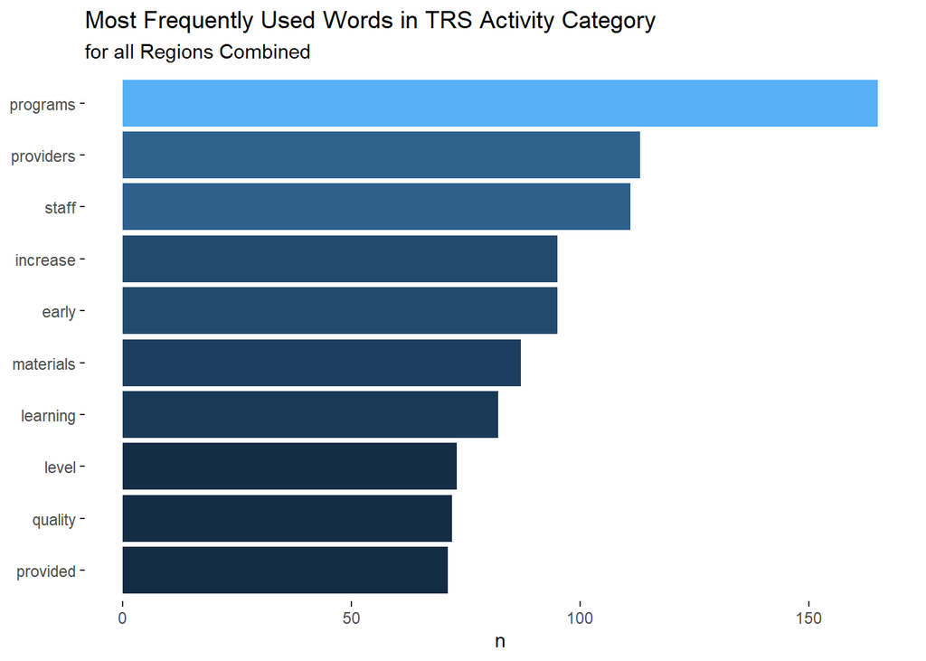

The below graph is supposed to show the top three words used for each region, but those that only use a few words will have more words listed, due to ties.

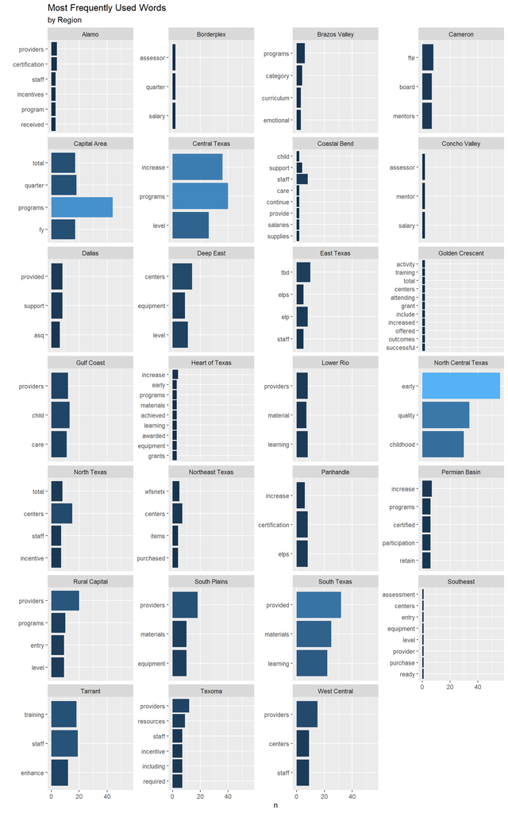

The below graph shows the regions that mention TRS, or the words Texas Rising Star, in non-TRS Activity Categories. There are regions like Concho Valley omitted because they had no mentions.

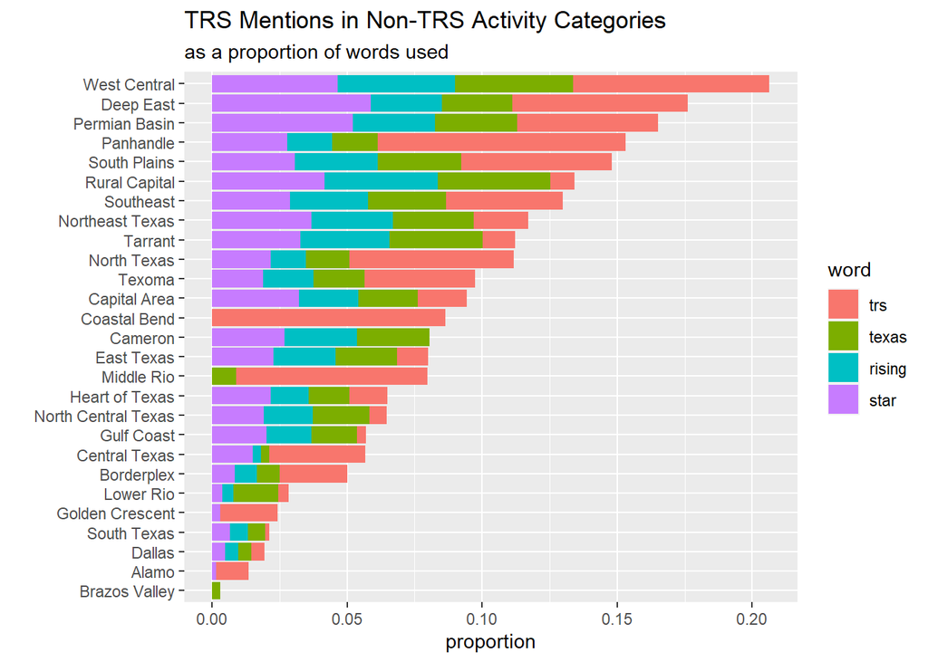

# Sentiment Analysis

Name: AFINN-111 URL: http://www2.imm.dtu.dk/pubdb/views/publication_details.php?id=6010 License: Open Database License (ODbL) v1.0

Citation info:

This dataset was published in Saif M. Mohammad and Peter Turney. (2013), ``Crowdsourcing a Word-Emotion Association Lexicon.’’ Computational Intelligence, 29(3): 436-465.

article{mohammad13, author = {Mohammad, Saif M. and Turney, Peter D.}, title = {Crowdsourcing a Word-Emotion Association Lexicon}, journal = {Computational Intelligence}, volume = {29}, number = {3}, pages = {436-465}, doi = {10.1111/j.1467-8640.2012.00460.x}, url = {https://onlinelibrary.wiley.com/doi/abs/10.1111/j.1467-8640.2012.00460.x}, eprint = {https://onlinelibrary.wiley.com/doi/pdf/10.1111/j.1467-8640.2012.00460.x}, year = {2013} } If you use this lexicon, then please cite it.

10 Most Frequently Used Sentiment Words

| sentiment | word | n |
| --- | --- | --- |
| positive | enhance | 41 |
| positive | support | 35 |
| positive | success | 30 |
| positive | awarded | 11 |
| positive | improving | 11 |
| positive | improvement | 8 |
| positive | improve | 7 |
| positive | supporting | 7 |
| positive | benefits | 6 |
| positive | effective | 6 |

Because “work” is seen as positive in this sentiment dataset, I removed it. In these texts I think it’s mostly a neutral term.

# Term Frequency - Inverse Document Frequency (tf-idf)

“The idea of tf-idf is to find the important words for the content of each document by decreasing the weight for commonly used words and increasing the weight for words that are not used very much in a collection or corpus of documents.”

None of these words occur in all of the texts. They are important, characteristic words for each region.

These have been limited to the top two terms that are unique to each region because some regions only had seven words to contribute. Additional words are listed if they have the same tf-idf value.

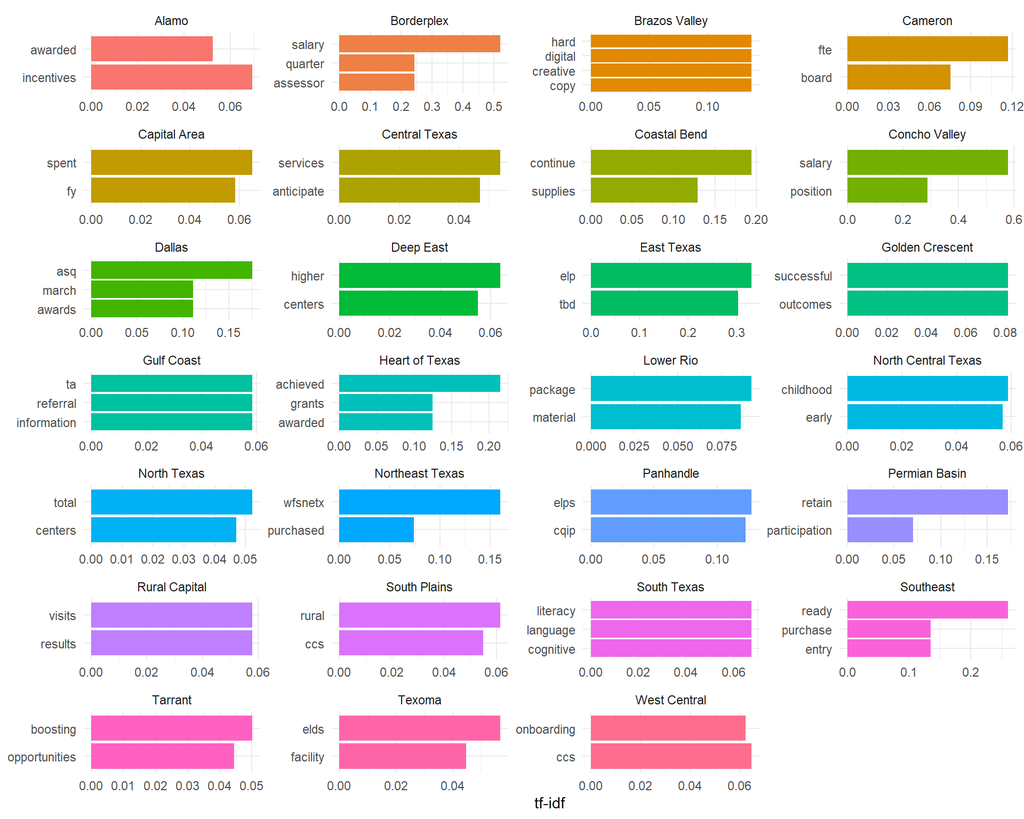

# N-Grams

## Bigrams

Examining pairs of two consecutive words, often called “bigrams”

10 most common bigrams overall

| word1 | word2 | n |
| --- | --- | --- |
| rising | star | 145 |
| texas | rising | 145 |
| early | learning | 53 |
| star | level | 51 |
| child | care | 38 |
| learning | programs | 36 |
| early | childhood | 31 |
| trs | certified | 30 |
| measure | success | 28 |
| entry | level | 21 |

| bigram | North Central Texas | Capital Area | Central Texas | Tarrant | South Texas | Rural Capital | Gulf Coast | Deep East | North Texas | Northeast Texas | West Central | Coastal Bend | Permian Basin | South Plains | Dallas | Texoma | Cameron | Lower Rio | Panhandle | Alamo | East Texas | Heart of Texas | Borderplex | Brazos Valley | Concho Valley | Golden Crescent | Southeast |
| --- | --- | --- | --- | --- | --- | --- | --- | --- | --- | --- | --- | --- | --- | --- | --- | --- | --- | --- | --- | --- | --- | --- | --- | --- | --- | --- | --- |
| early childhood | 30 | NA | NA | NA | NA | 1 | NA | NA | NA | NA | NA | NA | NA | NA | NA | NA | NA | NA | NA | NA | NA | NA | NA | NA | NA | NA | NA |
| rising star | 30 | 24 | 3 | 16 | 3 | 12 | 8 | 7 | 5 | 8 | 8 | NA | 6 | 2 | 1 | 3 | 1 | 4 | NA | NA | 2 | 1 | 1 | NA | NA | NA | NA |
| texas rising | 30 | 24 | 3 | 16 | 3 | 12 | 8 | 7 | 5 | 8 | 8 | NA | 6 | 2 | 1 | 3 | 1 | 4 | NA | NA | 2 | 1 | 1 | NA | NA | NA | NA |
| star level | 4 | 2 | 23 | NA | NA | NA | NA | 10 | 2 | NA | NA | NA | 4 | NA | NA | NA | NA | NA | 4 | 1 | NA | 1 | NA | NA | NA | NA | NA |
| trs certified | NA | NA | 19 | NA | NA | NA | 1 | 2 | 3 | NA | 1 | NA | 4 | NA | NA | NA | NA | NA | NA | NA | NA | NA | NA | NA | NA | NA | NA |
| early learning | 16 | 9 | 4 | NA | 14 | 4 | NA | NA | NA | NA | NA | NA | NA | NA | NA | NA | NA | 3 | NA | NA | NA | 3 | NA | NA | NA | NA | NA |
| child care | 14 | NA | NA | NA | 1 | 1 | 11 | 2 | 2 | NA | NA | 2 | 1 | NA | NA | NA | 1 | 2 | NA | 1 | NA | NA | NA | NA | NA | NA | NA |
| measure success | 2 | 13 | 13 | NA | NA | NA | NA | NA | NA | NA | NA | NA | NA | NA | NA | NA | NA | NA | NA | NA | NA | NA | NA | NA | NA | NA | NA |
| trs participation | NA | NA | 13 | NA | NA | NA | NA | NA | NA | NA | NA | NA | 4 | NA | NA | NA | NA | NA | NA | NA | NA | 1 | NA | NA | NA | NA | NA |
| childhood specialists | 13 | NA | NA | NA | NA | NA | NA | NA | NA | NA | NA | NA | NA | NA | NA | NA | NA | NA | NA | NA | NA | NA | NA | NA | NA | NA | NA |

Re-do the last chart to show the top ten bigrams by region instead.

TF-IDF for Bigrams

[figure not shown]

## Trigrams

I’m going to try it with stop words included because “out of school” is tricky otherwise (both “out” and “of” are stop words.)

Out of School Mentions

| trigram | Region | n |
| --- | --- | --- |

Youth Mentions with Stop Words Included

| trigram | n |
| --- | --- |

Youth Mentions without Stop Words

| trigram | n | rank |
| --- | --- | --- |

# Youth Sentiment

Note: “Disconnected” wasn’t in the sentiment dataset I used, so I manually added it.

[figure not shown]

# Word Associations

This section follows this tutorial : https://www.red-gate.com/simple-talk/databases/sql-server/bi-sql-server/text-mining-and-sentiment-analysis-with-r/

# Topic Modeling

“Latent Dirichlet allocation (LDA) is a particularly popular method for fitting a topic model. It treats each document as a mixture of topics, and each topic as a mixture of words.”

Idea: View the Board Oversight Capacity score card for your Board. Every year, the Texas Workforce Commission (TWC) assesses how well each Board uses local funds and provides local workforce services.